# 120 Lec 06

Tim Hagemeister

12 September, 2019

## Reading Discussion: Linear Regression

## Intro to Correlation and Linear Regression

we start with a scatterplot, an x and a y

## Examples: mpg data

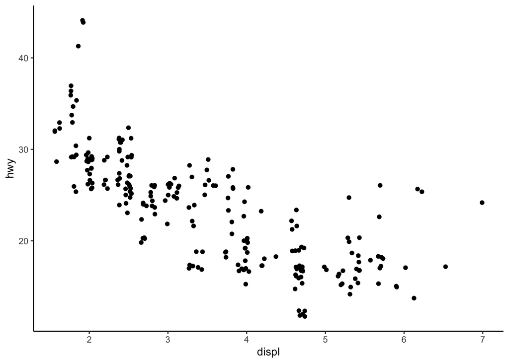

```r
ggplot(mpg, aes(x=displ, y=hwy))+
  geom_jitter()+
  theme_classic()
```

## Linear correlation coefficient: r

the correlation coefficient r measures the strength and the direction of the relationship,

if r is close to 1 then there is a strong positive relationship. if r is close to -1 then there is a strong negative relationsip. if r is close to 0 then there is no relationship.

fair warning: r only describes linear relationships. Ex on board: a semi circle can have a relatinship but the r can still be 0. a horizontal line also has a relationship but r is still 0. (y is not affected by x). Two lines, one has a steeper slope, both have corelation coefficient of 1.

## properties of r

- r is alwyas between -1< r <1
- does not matter which is x which is y
- r does not depend on units

## Example: 8.8 on page 314

1. D, 2) A, 3) C, 4) B

## Least Squares Equation

y = 41 + 0.59x

its a line, y = mx+b

in stats we use differnet letts

## The equation

yhat = b_1 *x + b_0

- b_1 is the slope
- b_0 is the intercept

## Example

```r
# in R we use lm as linear model

lm(hwy~cty, data = mpg)
```

```
##
## Call:
## lm(formula = hwy ~ cty, data = mpg)
##
## Coefficients:
## (Intercept)          cty
##       0.892        1.337
```

```r
cor(mpg$cty, mpg$hwy) # tells you r
```

```
## [1] 0.9559159
```

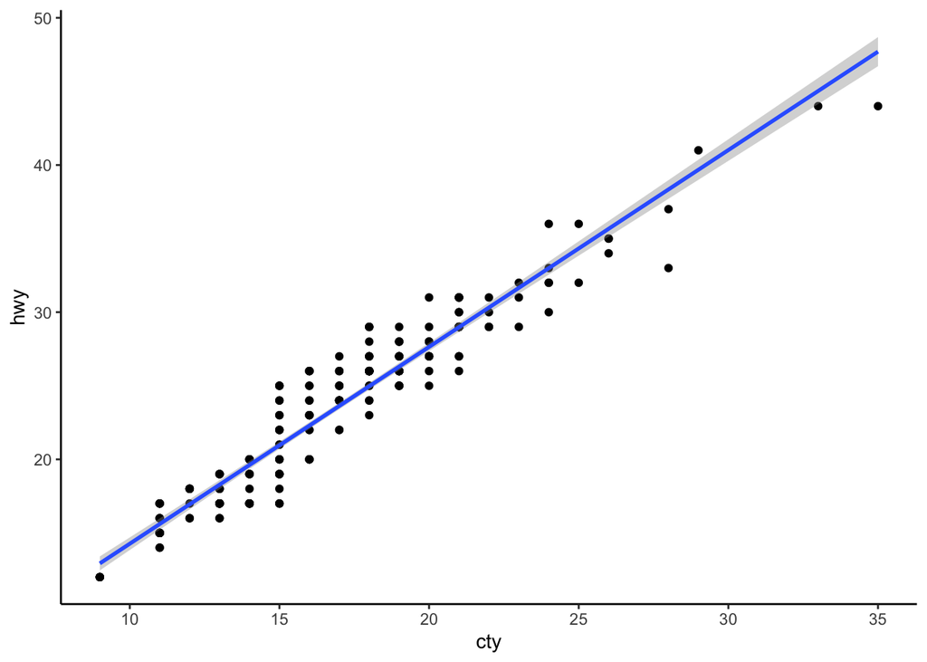

```r
ggplot(mpg, aes(x=cty, y=hwy))+
  geom_point()+
  geom_smooth(method = "lm")+
  theme_classic()
```

# observations

- the ~ has a special meaning: hwy is a function of cty. Note that y comes first: here thats why fuel efficiency
- were prediciting why based on city

## challange

```r
lm(cty~displ, data = mpg)
```

```
##
## Call:
## lm(formula = cty ~ displ, data = mpg)
##
## Coefficients:
## (Intercept)        displ
##       25.99        -2.63
```

```r
cor(mpg$cty, mpg$displ) # tells you r
```

```
## [1] -0.798524
```

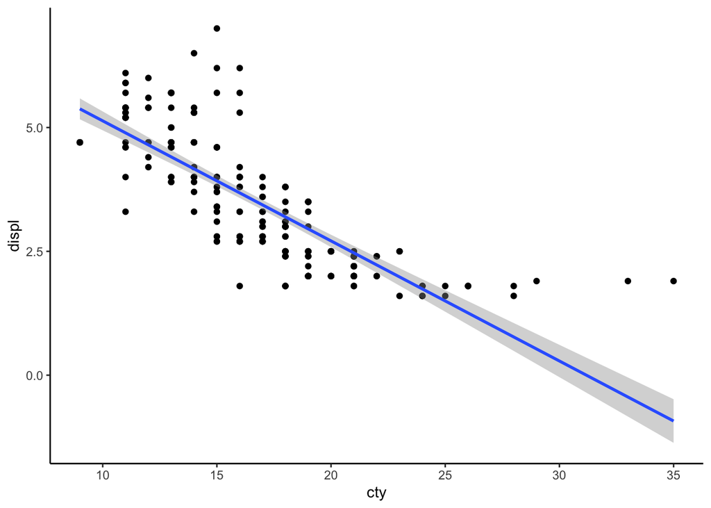

```r
ggplot(mpg, aes(x=cty, y=displ))+
  geom_point()+
  geom_smooth(method = "lm")+
  theme_classic()
```

## Uniqueness

the least - square line is unique, ie. the best linear mode.

This is a relif, we dont have to worry about **which line**

Names for the same thing:

- **Least square line**
- The Regression line
- The linear model
- The best fit line
- Other things that sound like that

## Idea behind deriving it

THe vertical distance (between lines and points) represents error! (BTW its called a residual.)

The last square line is the one that makes the square error as small as posisble

Question: why minimize square error:

(y-yhat)^2

some residuals are negative, some are posititve, we dont want hem to cancel out so we want to square to get all positive terms

the least squares line minimizes the square of the residuals. i.e. smallest square error

## Using lm in R

Weve seen lm before: example cty and hwy mpg

```r
lm(hwy ~ cty, data = mpg)
```

```
##
## Call:
## lm(formula = hwy ~ cty, data = mpg)
##
## Coefficients:
## (Intercept)          cty
##       0.892        1.337
```

the LM object has lots of cool properties about the model. save it, give it a name.

```r
mpgmodel <- lm(hwy ~ cty, data = mpg)
mpgmodel
```

```
##
## Call:
## lm(formula = hwy ~ cty, data = mpg)
##
## Coefficients:
## (Intercept)          cty
##       0.892        1.337
```

```r
summary(mpgmodel)
```

```
##
## Call:
## lm(formula = hwy ~ cty, data = mpg)
##
## Residuals:
##     Min      1Q  Median      3Q     Max
## -5.3408 -1.2790  0.0214  1.0338  4.0461
##
## Coefficients:
##             Estimate Std. Error t value Pr(>|t|)
## (Intercept)  0.89204    0.46895   1.902   0.0584 .
## cty          1.33746    0.02697  49.585   <2e-16 ***
## ---
## Signif. codes:  0 '***' 0.001 '**' 0.01 '*' 0.05 '.' 0.1 ' ' 1
##
## Residual standard error: 1.752 on 232 degrees of freedom
## Multiple R-squared:  0.9138, Adjusted R-squared:  0.9134
## F-statistic:  2459 on 1 and 232 DF,  p-value: < 2.2e-16
```

yhat = .892 + 1.337x

## Making predictions

R has built in prediction thingies, but dont use them, ites easy

EX: using this mode, predict the hwy fuel efficiency of a car that gets 30mpg in the city

easy to just use R as a calculator

```r
0.892+(1.337*30)
```

```
## [1] 41.002
```

following the linear mode, we predict that a car with 30 mpg in city would get 41.002 mpg on hwy

X is the explanatory variable, we think og it as causing an effect in y.

Y is the response variable, what were making predictions about

here in our graph, we can see that were using cty as x and hwy as y

thus were predicting hwy mpg based upon cty mpg

## Meaning of the coefficients

you can now get coeffs from lm. but what do they **mean**?

First: slope = b_1

## Meaning (math and graphical)

## Example: mpg data

## Interpreting Residual Plots